# Data Handling in Python: Clinical Study Design

# 4 Univariate Analysis

Take a look at each variable individually.

## 4.1 Numerical Variables

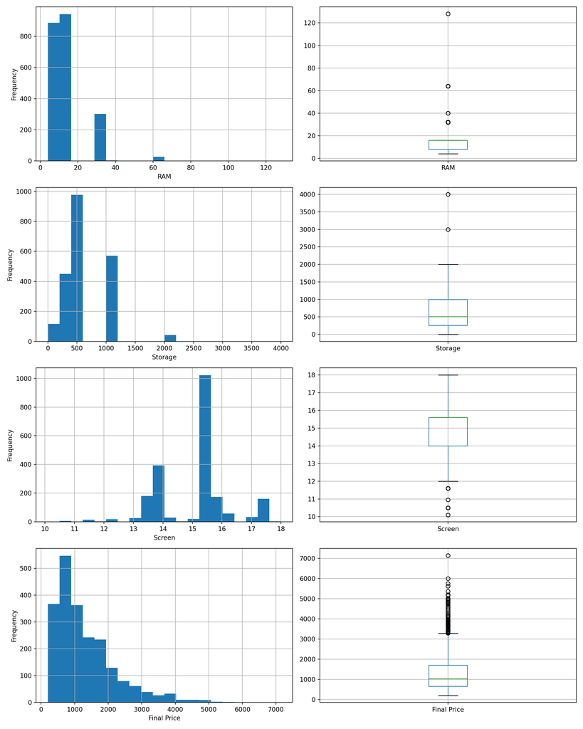

```python
fig, axs = plt.subplots(len(numerical), 2, figsize=(12.8, 16))

for i, var in enumerate(numerical):
    ax = axs[i, 0]
    ax.set_xlabel(var)
    ax.set_ylabel('Frequency')
    df[var].hist(bins=20, ax=ax)

    ax = axs[i, 1]
    df.boxplot(column=var, ax=ax)

fig.tight_layout()
plt.show()
```

## 4.2 Categorical Variables

Print the counts of each value that appears in the categorical columns:

```python
for i, var in enumerate(categorical):
    freq = df[var].value_counts()
    print(freq.head())
    print()
```

```
## Status
## New            1498
## Refurbished     662
## Name: count, dtype: int64
##
## Brand
## Asus      415
## HP        368
## Lenovo    366
## MSI       308
## Acer      137
## Name: count, dtype: int64
##
## Model
## 15S         115
## IdeaPad     104
## ROG         101
## VivoBook     99
## ThinkPad     99
## Name: count, dtype: int64
##
## CPU
## Intel Core i7    710
## Intel Core i5    535
## AMD Ryzen 7      156
## Intel Core i3    130
## AMD Ryzen 5      127
## Name: count, dtype: int64
##
## Storage type
## SSD     2062
## eMMC      56
## Name: count, dtype: int64
##
## GPU
## RTX 3050    129
## RTX 3060    122
## RTX 3070     97
## RTX 4060     62
## RTX 3080     51
## Name: count, dtype: int64
##
## Touch
## No     1933
## Yes     227
## Name: count, dtype: int64
```

Plot these counts:

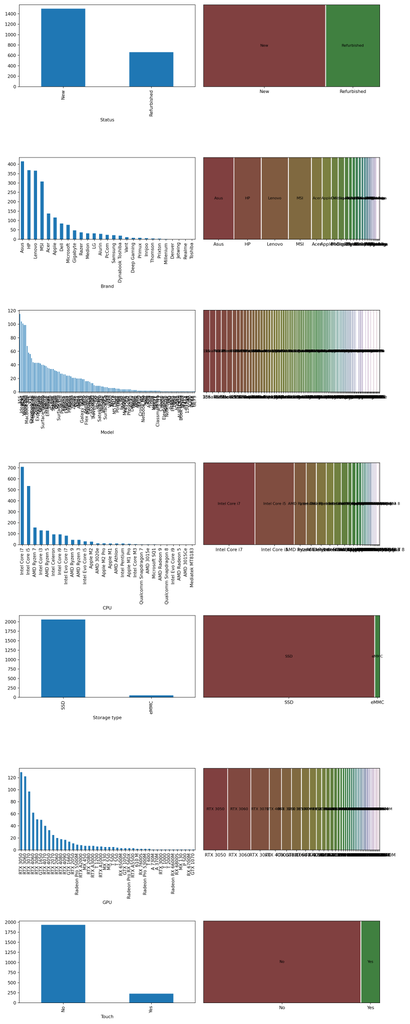

```python
fig, axs = plt.subplots(len(categorical), 2, figsize=(12.8, 32))

for i, var in enumerate(categorical):
    freq = df[var].value_counts()

    ax = axs[i, 0]
    freq.plot(kind='bar', ax=ax)

    ax = axs[i, 1]
    mosaic(freq.to_dict(), ax=ax)

fig.tight_layout()
plt.show()
```

# 5 Bivariate Analysis

Take a look at two variables at a time.

## 5.1 Numerical vs Numerical

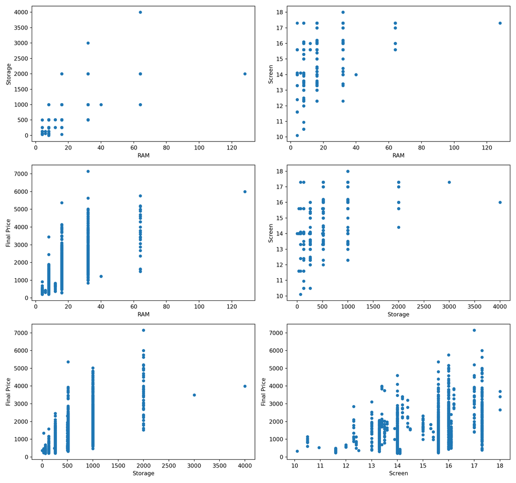

```python
fig, axs = plt.subplots(3, 2, figsize=(12.8, 12))
ax = axs[0, 0]
df.plot.scatter(x='RAM', y='Storage', ax=ax)
ax = axs[0, 1]
df.plot.scatter(x='RAM', y='Screen', ax=ax)
ax = axs[1, 0]
df.plot.scatter(x='RAM', y='Final Price', ax=ax)
ax = axs[1, 1]
df.plot.scatter(x='Storage', y='Screen', ax=ax)
ax = axs[2, 0]
df.plot.scatter(x='Storage', y='Final Price', ax=ax)
ax = axs[2, 1]
df.plot.scatter(x='Screen', y='Final Price', ax=ax)
fig.tight_layout()
plt.show()
```

Correlation heatmap:

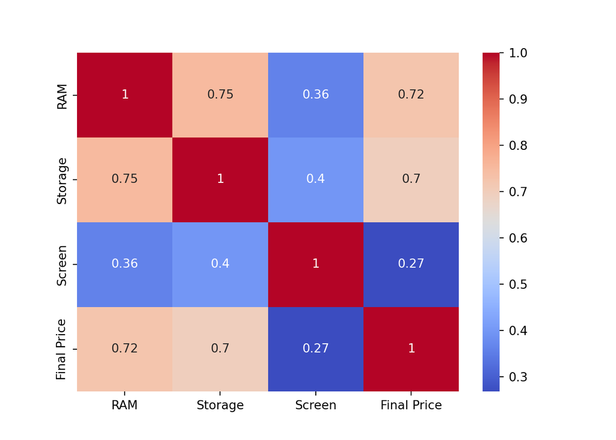

```python
corr = df.corr(numeric_only=True)
sns.heatmap(corr, annot=True, cmap='coolwarm')
plt.show()
```

## 5.2 Categorical vs Numerical

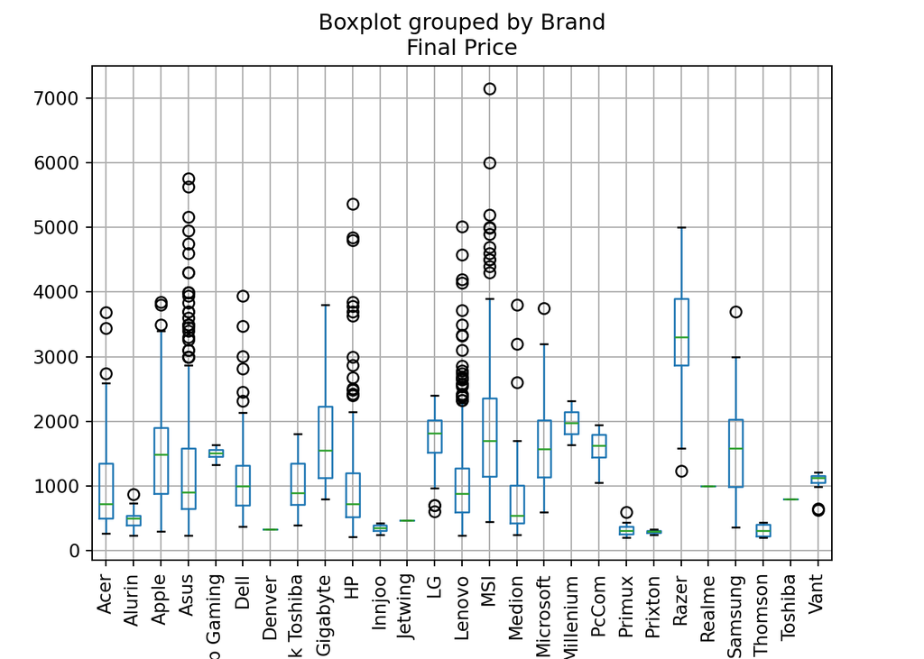

```python
df.boxplot(column='Final Price', by='Brand', rot=90)
plt.show()
```

## 5.3 Categorical vs Categorical

```python
pd.crosstab(df['Status'], df['Touch'])
```

```
## Touch          No  Yes
## Status
## New          1320  178
## Refurbished   613   49
```

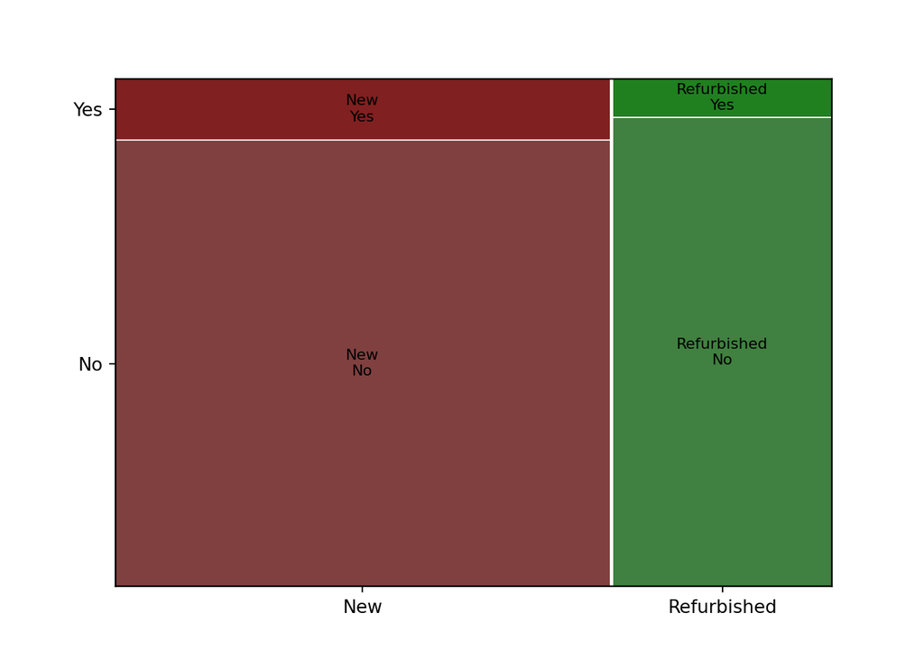

```python
mosaic(df, ['Status', 'Touch'])
plt.show()
```

# 6 Outlier Detection

Outliers may or may not be relevant in an analysis and so the way in which they get handled depends on a number of factors that are usually specific to the analysis method being used. Regardless, identifying unusual values that might affect the analysis down the line is a useful step in the initial data exploration phase.

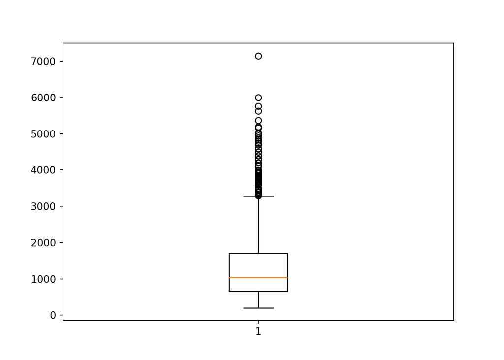

```python
bp = plt.boxplot(df['Final Price'])
plt.show()
```

```python
q1 = df['Final Price'].quantile(0.25)
q3 = df['Final Price'].quantile(0.75)
iqr = q3 - q1
outliers = df[(df['Final Price'] < q1 - 1.5*iqr) | (df['Final Price'] > q3 + 1.5*iqr)]
print(outliers.head())
```

```
##     Status  Brand  Model            CPU  RAM  Storage Storage type       GPU  Screen Touch  Final Price
## 100    New  Razer  Blade  Intel Core i7   16     1000          SSD  RTX 3070    15.6    No      3299.99
## 292    New   Asus    ROG  Intel Core i9   32     1000          SSD  RTX 4090    16.0    No      3699.01
## 307    New   Asus    ROG  Intel Core i9   32     1000          SSD  RTX 4090    18.0    No      3699.01
## 351    New   Asus    ROG  Intel Core i9   32     1000          SSD  RTX 4080    16.0    No      3599.00
## 361    New   Asus    ROG  Intel Core i9   32     1000          SSD  RTX 4080    18.0    No      3399.00
```

# 7 Handle Duplicates

Similar to outliers, the way in which duplicates get handled depends on the exact analysis method being used. The code below simply removes them:

```python
print(df.duplicated().sum())
```

```
## 62
```

```python
df = df.drop_duplicates()
```

# 8 Summary

Exploratory Data Analysis (EDA) is a crucial first step in any data science workflow:

- It helps in understanding the structure, quality and patterns that exist in the data before moving on to modelling
- EDA includes data profiling, visualisation and statistical exploration
- The above help to uncover missing values, outliers, relationships and distributions that can significantly impact results
- The exploratory process can help to validate model assumptions, highlight potential biases and/or reveal new insights or features

Doing EDA at the start of a process makes it easier to have faith in the reliability of the downstream analysis. It also helps in focussing on the research and statistical questions that need to be answered as, ultimately, these are what need to be answered by the data.

⇦ Back